# Our love in text messages

Gil Henriques

2020-02-14

## A love letter 💌

Dear sweetheart,

This is a Valentine’s Day love letter to celebrate our relationship.

Let’s start by loading some packages. 📦

```r
library(tidyverse)
library(lubridate)
library(cowplot)
library(ggridges)
library(ggrepel)
library(tidytext)
library(igraph)
library(ggraph)
library(scales)
library(sf)
library(patchwork)
library(hrbrthemes)
import_roboto_condensed()
update_geom_font_defaults(font_rc)
```

I started by downloading our WhatsApp chat history. 💬 Here’s what it looks like:

```r
chat <- read_csv("_chat.txt", col_names = c("date", "text"))
chat
```

```
## # A tibble: 17,504 x 2
##    date        text
##    <chr>       <chr>
##  1 [2017-10-15 "09:16:57] Sötnos \U0001f60d: Messages to this chat and ca~
##  2 [2017-10-15 09:17:12] Gil Henriques: Did you call me?
##  3 [2017-10-15 "09:17:13] Sötnos \U0001f60d: Missed video call"
##  4 [2017-10-15 "09:17:20] Sötnos \U0001f60d: Yeah"
##  5 [2017-10-15 "09:17:28] Sötnos \U0001f60d: Why doesn't it work? :O"
##  6 [2017-10-15 09:17:31] Gil Henriques: I called you back but you didn't p~
##  7 [2017-10-15 09:17:35] Gil Henriques: Will try again
##  8 [2017-10-15 09:18:14] Gil Henriques: Weird
##  9 [2017-10-15 09:18:24] Gil Henriques: Called you three times now you don~
## 10 [2017-10-15 09:18:46] Gil Henriques: Anyway what did you want to tell m~
## # ... with 17,494 more rows
```

As you can see, it’s a mess! We need to clean it up a little before we continue. 🧹

```r
chat <- chat %>%
  filter(!str_detect(text, "omitted")) %>% # Remove messages saying "Image omitted", "video omitted", etc
  unnest_tokens(word, text) %>% # Separates each word into a row and makes them lowercase
  filter(!(word %in% c("gil", "henriques", "sötnos", "linnea", "sandell"))) %>% # remove usernames
  filter(!str_detect(word, "[0-9]")) %>%  # remove numbers
  filter(!str_detect(word, "'")) %>%  # remove contractions
  filter(!str_detect(word, "^[a-z]$")) %>% # remove single letters (doesn't work with accents)
  mutate(date = ymd(date))
chat
```

```
## # A tibble: 98,899 x 2
##    date       word
##    <date>     <chr>
##  1 2017-10-15 messages
##  2 2017-10-15 to
##  3 2017-10-15 this
##  4 2017-10-15 chat
##  5 2017-10-15 and
##  6 2017-10-15 calls
##  7 2017-10-15 are
##  8 2017-10-15 now
##  9 2017-10-15 secured
## 10 2017-10-15 with
## # ... with 98,889 more rows
```

Now, let’s see what we can find out from here!

## Common words

What words do we use most often?

```r
wordlist <- chat %>%
  select(word) %>%
  group_by(word) %>%
  summarise(n = n()) %>%
  ungroup()

wordlist %>% arrange(desc(n))
```

```
## # A tibble: 7,551 x 2
##    word      n
##    <chr> <int>
##  1 you    3350
##  2 the    3305
##  3 to     3200
##  4 and    2225
##  5 so     1355
##  6 in     1337
##  7 it     1283
##  8 for    1145
##  9 is     1137
## 10 will   1063
## # ... with 7,541 more rows
```

Many common words are simply words that are used often, such as “you”, “the”, or “for”. Let’s get rid of some of these:

```r
wordlist <- wordlist %>%
  filter(!word %in% stop_words[stop_words$lexicon == "snowball",]$word)
wordlist %>% arrange(desc(n))
```

```
## # A tibble: 7,432 x 2
##    word      n
##    <chr> <int>
##  1 will   1063
##  2 can     890
##  3 go      799
##  4 now     795
##  5 home    774
##  6 ok      774
##  7 just    562
##  8 like    532
##  9 good    487
## 10 get     471
## # ... with 7,422 more rows
```

That’s already better, but what we really want is to compare each word to how commonly they are used in English. So, we will need a wordlist of English words and their relative frequencies. 📖

I downloaded a corpus of 4934 college student American English SMS text messages created by Daniel R. O’Day of the [Cyber Security Lab](https://web.archive.org/web/20130921043042/http://cybersecurity.cit.purduecal.edu/content/tmcorpus.html) at Purdue University.

```r
corpus <- read_delim("texts.txt", "\t", escape_double = FALSE, trim_ws = TRUE) %>%
  unnest_tokens(word, message_body) %>% # Separates each word into a row and makes them lowercase
  filter(!str_detect(word, "[0-9]"), class == 0) %>%  # remove numbers
  select(word) %>%
  group_by(word) %>%
  summarise(n = n()) %>%
  ungroup() %>%
  arrange(desc(n)) %>%
  mutate(source = "corpus") %>%
  filter(!word %in% stop_words[stop_words$lexicon == "snowball",]$word)
corpus
```

```
## # A tibble: 4,130 x 3
##    word      n source
##    <chr> <int> <chr>
##  1 u       524 corpus
##  2 ok      328 corpus
##  3 will    321 corpus
##  4 can     250 corpus
##  5 just    248 corpus
##  6 get     213 corpus
##  7 lol     194 corpus
##  8 know    185 corpus
##  9 now     165 corpus
## 10 going   153 corpus
## # ... with 4,120 more rows
```

```r
wordlist$source <- "chat"
df <- bind_rows(wordlist, corpus)
```

We will use a metric called TFIDF, when means “term frequency - inverse document frequency”, whose value is higher for words that are more common in the chat history, and lower for words that are very common in the English language corpus:

[figure not shown]

```r
df %>%
  bind_tf_idf(word, source, n) %>%
  filter(source == "chat") %>%
  arrange(desc(tf_idf)) %>%
  mutate(word = factor(word, levels = rev(unique(word)))) %>%
  top_n(50) %>%
  ggplot(aes(word, tf_idf)) +
  geom_col(fill = "steelblue", alpha = 0.7) +
  labs(x = NULL, y = "tf-idf") +
  coord_flip() +
  theme_ipsum_rc(grid = "X") +
  ylab("TFIDF (Frequency of word compared to American English college student text messages)") +
  labs(title = "What words distinguish our chats\nfrom average English texts?") +
  scale_y_continuous(label = function(x) {ifelse(x == 0, "0", parse(text=gsub("[+]", "", gsub("e", " %*% 10^", scientific_format()(x)))))})
```

There is a lot of interesting stuff going on here! Themes that distinguish our messages include:

- Friends, family, and pets (“Ailene”, “Eva”, “Newton”, “Leonard”, “Neo”, “Brooke”) 👨‍👩‍👧‍👦
- Work (“BRC”, “Sally”, “TA”, “Marking”, “EDG”, “Matt”, “Seminar”, “Theory”) 📝
- Food (“Bread”, “Vegan”, “Salad”, “Tasty”, “Fruit”) 🥑
- Languages (“Jag”, “Swedish”, “Du”, “Portuguese”, “Är”, “Duolingo”, “Det”) 🇵🇹 🇸🇪

## Sentiment analysis

Sentiment analysis tells us whether the messages we are sending are positive or negative. We can start by finding the most used “positive” 👍 and “negative” 👎 words:

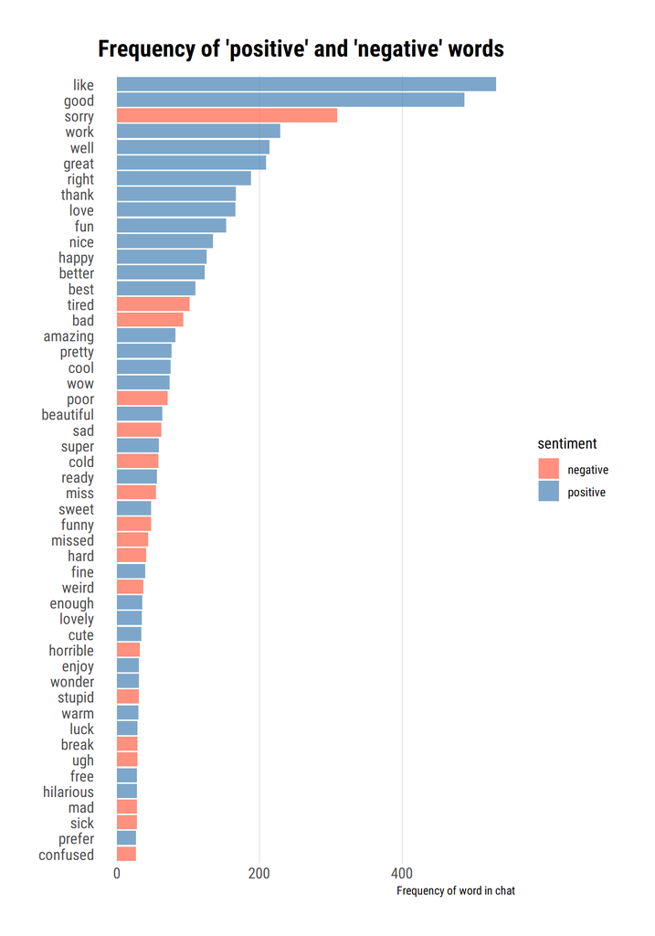

```r
bing_positive <- get_sentiments("bing") %>%
  filter(sentiment == "positive")
bing_negative <- get_sentiments("bing") %>%
  filter(sentiment == "negative")

positive_words <- wordlist %>%
  uncount(n) %>%
  inner_join(bing_positive) %>%
  count(word, sort = TRUE) %>%
  mutate(sentiment = "positive")

negative_words <- wordlist %>%
  uncount(n) %>%
  inner_join(bing_negative) %>%
  count(word, sort = TRUE) %>%
  mutate(sentiment = "negative")

bind_rows(positive_words, negative_words) %>%
  arrange(desc(n)) %>%
  mutate(word = factor(word, levels = rev(unique(word)))) %>%
  top_n(50, n) %>%
  ggplot(aes(word, n, fill = sentiment)) +
  geom_col(alpha = 0.7) +
  labs(x = NULL, y = "count") +
  coord_flip() +
  theme_ipsum_rc(grid = "X") +
  ylab("Frequency of word in chat") +
  labs(title = "Frequency of 'positive' and 'negative' words") +
  scale_fill_manual(values = c("tomato", "steelblue"))
```

We can also study how the sentiment changes over time. 📈

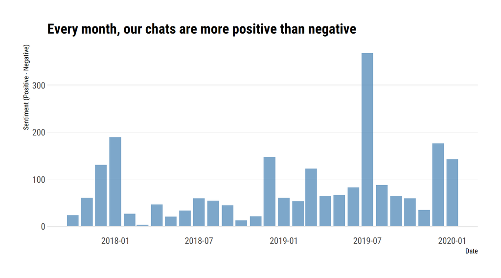

```r
timeline <- chat %>%
  mutate(month = month(date), year = year(date)) %>%
  filter(!word %in% stop_words[stop_words$lexicon == "snowball",]$word)

timeline <- timeline[!(timeline$word %>% str_detect("'")),]
timeline <- timeline[!(timeline$word %>% str_detect("^[a-z]$")),]

timeline %>%
  inner_join(bind_rows(bing_positive, bing_negative)) %>%
  group_by(year, month, sentiment) %>%
  summarize(n = n()) %>%
  ungroup() %>%
  pivot_wider(names_from = sentiment, values_from = n) %>%
  mutate(date = lubridate::parse_date_time(paste(month, year, sep = "/"), "mY")) %>%
  ggplot(aes(x = date, y = positive-negative)) +
  geom_col(fill = "steelblue", alpha = 0.7) +
  theme_ipsum_rc(grid = "Y") +
  xlab("Date") + ylab("Sentiment (Positive - Negative)") +
  labs(title = "Every month, our chats are more positive than negative")
```

It is clear that we use more positive than negative words. But *how* positive? So far we have been using a ternary scale—each word is either positive, or negative, or neutral. But we can also use a sentiment scale that ranges from very negative to very positive. Then, we can study how the frequency of each word correlates with its sentiment:

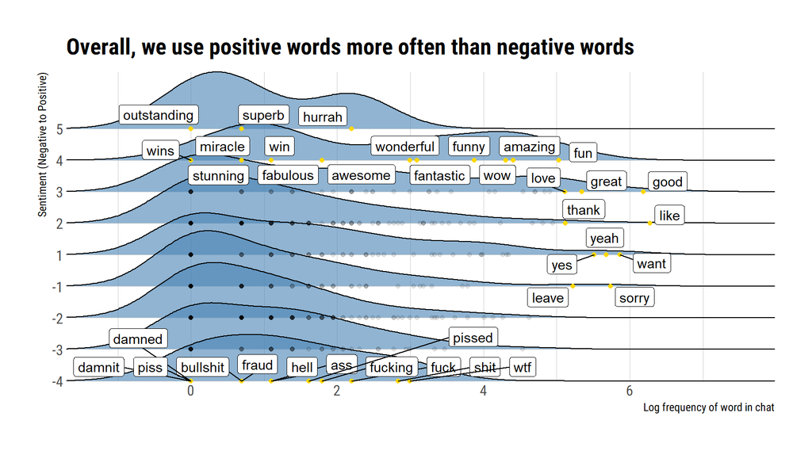

```r
afinn <- get_sentiments("afinn")

afinn_wordlist <- wordlist %>%
  inner_join(afinn) %>%
  mutate(label = if_else(log(n) > 5 | value %in% c(-4, 4, 5), word, ""))

afinn_wordlist %>%
  ggplot(aes(x = log(n), y = as.factor(value), label = label)) +
  geom_density_ridges(fill = "steelblue",
                      quantiles = 2,
                      alpha = 0.6,
                      jittered_points = F,
                      point_alpha = 0.3) +
  scale_x_continuous(expand = c(0, 0)) +
  scale_y_discrete(expand = c(0, 0)) +
  coord_cartesian(clip = "off") +
  theme_ipsum_rc() +
  geom_point(aes(alpha = if_else(label == "", 0.2, 1)),
                 color = if_else(afinn_wordlist$label == "", "black", "gold")) +
  geom_label_repel() +
  theme(legend.position = "none") +
  xlab("Log frequency of word in chat") + ylab("Sentiment (Negative to Positive)") +
  labs(title = "Overall, we use positive words more often than negative words")
```

In the figure above, I highlighted very negative (-4), very positive (4-5), and very common (>5) words. Although the pattern is not super strong, words we use most frequently are often more positive.

“Positive” and “negative” is not all there is to sentiment. There are many different types of sentiments. The next figure identifies what kinds of sentiments are most common in our chats:

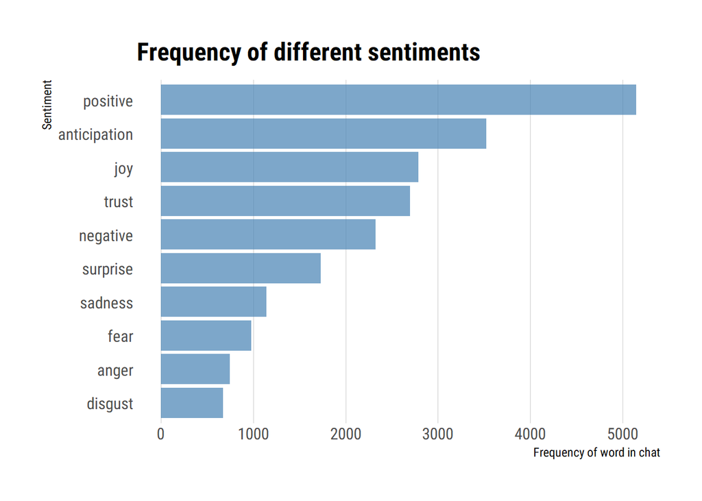

```r
wordlist %>%
  uncount(n) %>%
  select(word) %>%
  inner_join(get_sentiments("nrc")) %>%
  group_by(sentiment) %>%
  summarize(n = n()) %>%
  ggplot(aes(x = fct_reorder(sentiment, n), y = n)) +
  geom_col(fill = "steelblue", alpha = 0.7) +
  coord_flip() +
  theme_ipsum_rc(grid = "X") +
  ylab("Frequency of word in chat") +
  xlab("Sentiment") +
  labs(title = "Frequency of different sentiments")
```

## Correlations between words

Words don’t exist in a vaccuum. We can also focus on words that often appear together. Every pair of words is called a bigram.

```r
chat_bigrams <- read_csv("_chat.txt", col_names = c("date", "text")) %>%
  unnest_tokens(word, text) %>%
  filter(!(word %in% c("gil", "henriques", "sötnos", "linnea", "sandell"))) %>% # remove usernames
  filter(!str_detect(word, "[0-9]")) %>%# remove numbers
  filter(!str_detect(word, "'")) %>%# remove contractions
  unnest_tokens(bigram, word, token = "ngrams", n = 2) %>%  # make everything lowercase
  select(bigram)

bigrams_separated <- chat_bigrams %>%
  separate(bigram, c("word1", "word2"), sep = " ")

bigrams_filtered <- bigrams_separated %>%
  filter(!word1 %in% stop_words[stop_words$lexicon == "snowball",]$word) %>%
  filter(!word2 %in% stop_words[stop_words$lexicon == "snowball",]$word)

bigram_counts <- bigrams_filtered %>%
  count(word1, word2, sort = TRUE)

bigram_counts
```

```
## # A tibble: 19,878 x 3
##    word1   word2       n
##    <chr>   <chr>   <int>
##  1 image   omitted   645
##  2 omitted image     478
##  3 go      home      199
##  4 will    go        122
##  5 going   home       84
##  6 home    now        83
##  7 sticker omitted    76
##  8 can     go         75
##  9 right   now        54
## 10 feel    like       50
## # ... with 19,868 more rows
```

Now we have each bigram and the number of times it appears in our chat.

⚠️ “Image omitted” appears a lot because I imported the WhatsApp history into a text file, so every image or photo we ever sent each other is replaced with this message. 🖼

The data above can be used to create an plot a network:

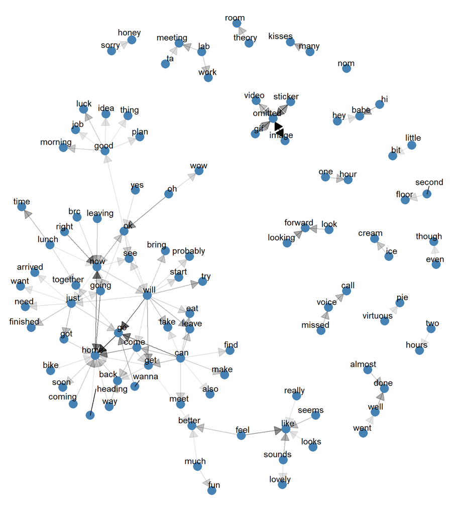

```r
bigram_graph <- bigram_counts %>%
  filter(n > 10) %>%
  graph_from_data_frame()

a <- grid::arrow(type = "closed", length = unit(.15, "inches"))

ggraph(bigram_graph, layout = "fr") +
  geom_edge_link(aes(edge_alpha = log(n)+0.2), show.legend = FALSE,
                 arrow = a, end_cap = circle(.07, 'inches')) +
  geom_node_point(color = "steelblue", size = 5) +
  geom_node_text(aes(label = name), vjust = 1, hjust = 1, repel = T) +
  theme_void()
```

Follow the arrows between the blue points and you can see most of our most common text messages!

## Comparing Gil and Linnéa’s texts

Since we are together all the time, you would be excused for thinking that we are, in fact, the same person. 👫 But the truth is that we are actually different, and that means we write differently as well.

We can verify this by studying our WhatsApp texts by author.

```r
chat_by_person <- read_csv("_chat.txt", col_names = c("date", "text")) %>%
  separate(text, into = c("person", "text"), sep= " \U0001f60d:| Henriques:") %>%
  separate(person, into = c(NA, "person"), sep = "] ") %>%
  mutate(person = fct_recode(person, Linnea = "Sötnos")) %>%
  mutate(date = ymd(date)) %>%
  filter(!str_detect(text, "omitted")) %>% # Remove messages saying "Image omitted", "video omitted", etc
  unnest_tokens(word, text) %>%
  filter(!word %in% stop_words[stop_words$lexicon == "snowball",]$word,
         str_detect(word, "[a-z]"))
chat_by_person %>% tail()
```

```
## # A tibble: 6 x 3
##   date       person word
##   <date>     <fct>  <chr>
## 1 2020-01-31 Gil    chickpeas
## 2 2020-01-31 Gil    fridge
## 3 2020-01-31 Gil    amazing
## 4 2020-01-31 Linnea yeah
## 5 2020-01-31 Linnea try
## 6 2020-01-31 Linnea whip
```

The first thing we can do is look at how frequently each of us uses each word:

```r
frequency <- chat_by_person %>%
  group_by(person) %>%
  count(word, sort = TRUE) %>%
  left_join(chat_by_person %>% group_by(person) %>% summarise(total = n())) %>%
  mutate(freq = n/total) %>%
  select(person, word, freq) %>%
  pivot_wider(names_from = person, values_from = freq) %>%
  filter(nchar(word) > 1) %>%
  drop_na()
frequency
```

```
## # A tibble: 2,607 x 3
##    word      Gil  Linnea
##    <chr>   <dbl>   <dbl>
##  1 will  0.0258  0.0105
##  2 now   0.0173  0.0103
##  3 can   0.0154  0.0157
##  4 ok    0.0111  0.0162
##  5 go    0.0143  0.0136
##  6 home  0.0119  0.0154
##  7 just  0.00846 0.0113
##  8 like  0.00799 0.0107
##  9 good  0.00866 0.00838
## 10 get   0.00728 0.00918
## # ... with 2,597 more rows
```

Calculating the distance to the $x=y$ line, we can identify the words that most distinguish me from you.

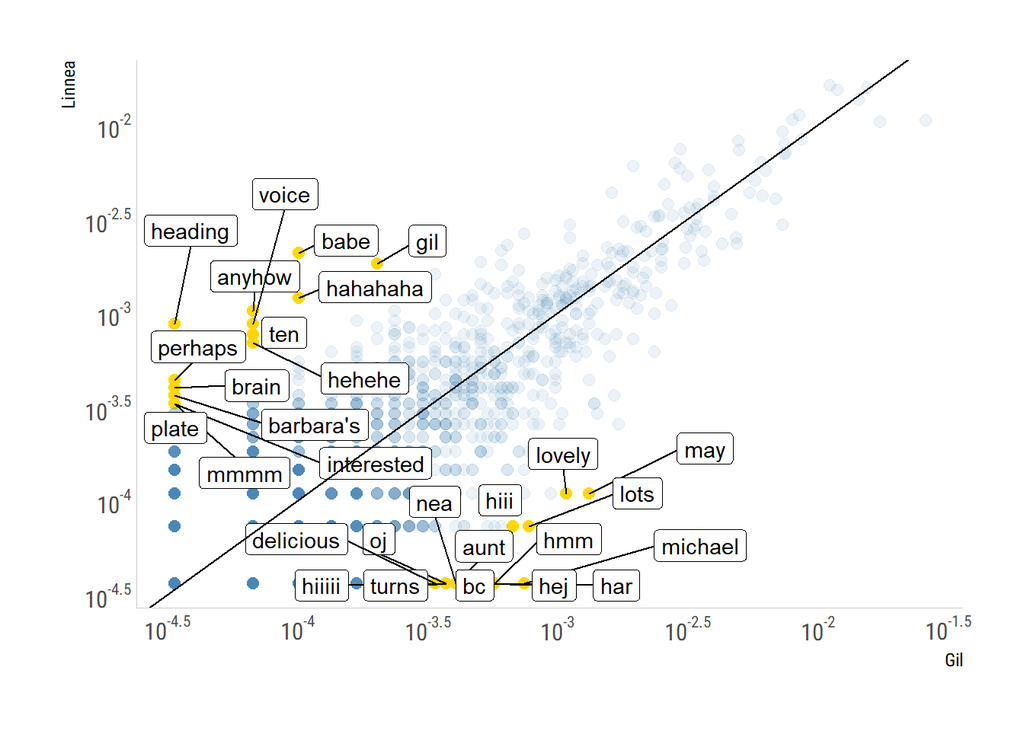

```r
frequency <- frequency %>%
  mutate(distance_to_xy = sqrt((log(Linnea) - log(Gil))^2 / 2))

frequency %>%
  ggplot(aes(Gil, Linnea)) +
  geom_point(alpha = if_else(frequency$distance_to_xy > 1.55, 1, 0.1),
              color = if_else(frequency$distance_to_xy > 1.55, "gold", "steelblue"),
              size = 2.5) +
  geom_label_repel(data = filter(frequency, distance_to_xy > 1.55), aes(label = word)) +
  scale_x_log10(breaks = trans_breaks("log10", function(x) 10^x),
                labels = trans_format("log10", math_format(10^.x))) +
  scale_y_log10(breaks = trans_breaks("log10", function(x) 10^x),
                labels = trans_format("log10", math_format(10^.x))) +
  geom_abline() +
  theme_ipsum_rc(grid = "", axis = "xy")
```

Clearly, our texts share many words in common, but some words appear more commonly in my writing (“Néa”, “Michael”, “lovely”, and a lot of Swedish text), whereas other words are more frequent in your texts (“Babe”, “Gil”, “brain”, “Barbara’s”).

A better way to quantify the words that are more likely to come from me or from you is using a log odds ratio:

```r
word_ratios <- chat_by_person %>%
  count(word, person) %>%
  filter(nchar(word) > 1) %>%
  group_by(word) %>%
  filter(sum(n) >= 10) %>%
  ungroup() %>%
  spread(person, n, fill = 0) %>%
  mutate_if(is.numeric, list(~(. + 1) / (sum(.) + 1))) %>%
  mutate(logratio = log(Gil / Linnea)) %>%
  arrange(desc(logratio))
word_ratios
```

```
## # A tibble: 876 x 4
##    word          Gil    Linnea logratio
##    <chr>       <dbl>     <dbl>    <dbl>
##  1 ooh      0.000819 0.0000489     2.82
##  2 hahah    0.000637 0.0000489     2.57
##  3 iris     0.000637 0.0000489     2.57
##  4 sötnos   0.000637 0.0000489     2.57
##  5 boarding 0.000592 0.0000489     2.49
##  6 hahahah  0.000592 0.0000489     2.49
##  7 although 0.000546 0.0000489     2.41
##  8 depart   0.000546 0.0000489     2.41
##  9 michael  0.00105  0.0000979     2.37
## 10 queue    0.000501 0.0000489     2.33
## # ... with 866 more rows
```

Here are some words that are about equally likely:

```r
word_ratios %>%
  arrange(abs(logratio))
```

```
## # A tibble: 876 x 4
##    word         Gil   Linnea logratio
##    <chr>      <dbl>    <dbl>    <dbl>
##  1 episode 0.000637 0.000636  0.00192
##  2 talking 0.000683 0.000685 -0.00320
##  3 found   0.00123  0.00122   0.00477
##  4 rest    0.00182  0.00181   0.00577
##  5 work    0.00542  0.00538   0.00645
##  6 able    0.000728 0.000734 -0.00765
##  7 break   0.000728 0.000734 -0.00765
##  8 hug     0.000592 0.000587  0.00785
##  9 plan    0.00118  0.00117   0.00785
## 10 real    0.000592 0.000587  0.00785
## # ... with 866 more rows
```

And what are the most distinctive words?

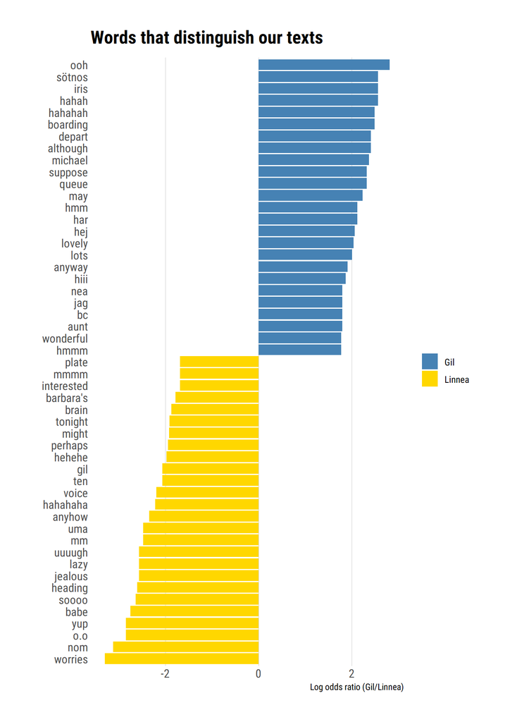

```r
word_ratios %>%
  group_by(logratio < 0) %>%
  top_n(25, abs(logratio)) %>%
  ungroup() %>%
  mutate(word = reorder(word, logratio)) %>%
  ggplot(aes(word, logratio, fill = logratio < 0)) +
  geom_col() +
  coord_flip() +
  ylab("Log odds ratio (Gil/Linnea)") + xlab("") +
  labs(title = "Words that distinguish our texts") +
  scale_fill_manual(name = "", labels = c("Gil", "Linnea"), values = c("steelblue","gold")) +
  theme_ipsum_rc(grid = "X")
```

Just like we don’t use the same words, our texts also have different sentiments:

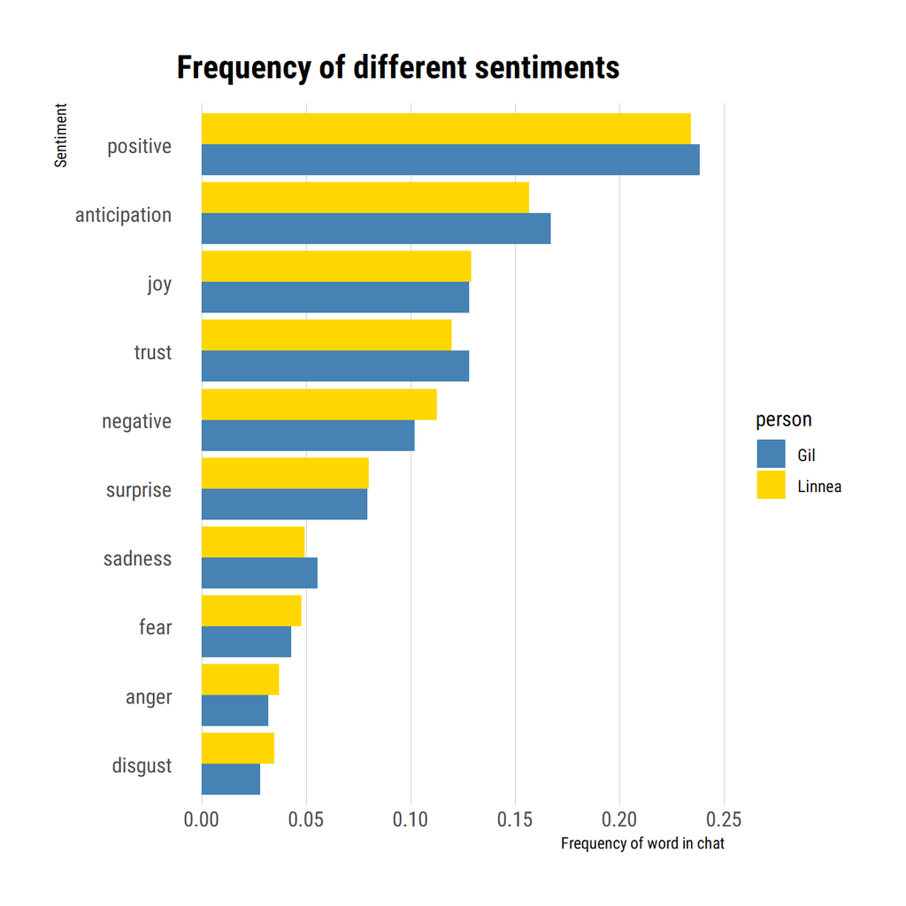

```r
chat_by_person %>%
  select(person, word) %>%
  inner_join(get_sentiments("nrc")) %>%
  group_by(person, sentiment) %>%
  summarize(n = n()) %>%
  ungroup() %>%
  group_by(person) %>%
  mutate(frequency = n/sum(n)) %>%
  ungroup() %>%
  ggplot(aes(x = fct_reorder(sentiment, frequency), y = frequency, group = person, fill = person)) +
  geom_col(position = "dodge") +
  coord_flip() +
  theme_ipsum_rc(grid = "X") +
  ylab("Frequency of word in chat") +
  xlab("Sentiment") +
  scale_fill_manual(values = c("steelblue", "gold")) +
  labs(title = "Frequency of different sentiments")
```

And those sentiments also change over time:

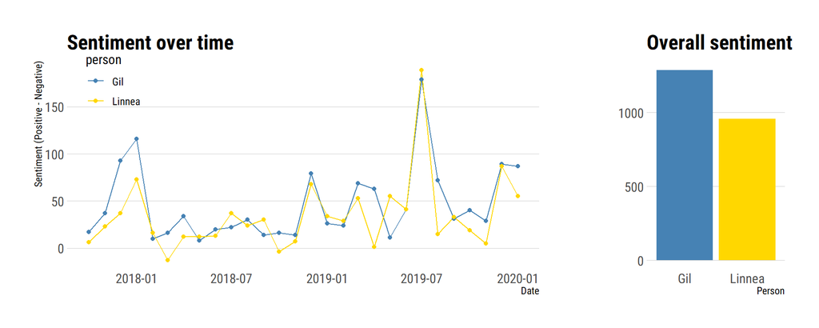

```r
time_plot <- chat_by_person %>%
  mutate(month = month(date), year = year(date)) %>%
  inner_join(bind_rows(bing_positive, bing_negative)) %>%
  group_by(person, year, month, sentiment) %>%
  summarize(n = n()) %>%
  ungroup() %>%
  pivot_wider(names_from = sentiment, values_from = n) %>%
  mutate(date = lubridate::parse_date_time(paste(month, year, sep = "/"), "mY")) %>%
  ggplot(aes(x = date, y = positive-negative, group = person, color = person)) +
  geom_line() +
  geom_point() +
  theme_ipsum_rc(grid = "Y") +
  theme(legend.position = c(0.1,0.9)) +
  xlab("Date") + ylab("Sentiment (Positive - Negative)") +
  labs(title = "Sentiment over time") +
  scale_color_manual(values = c("steelblue", "gold"))


total_plot <- chat_by_person %>%
  inner_join(bind_rows(bing_positive, bing_negative)) %>%
  group_by(person, sentiment) %>%
  summarize(n = n()) %>%
  ungroup() %>%
  pivot_wider(names_from = sentiment, values_from = n) %>%
  ggplot(aes(x = person, y = positive-negative, fill = person)) +
  geom_col() +
  theme_ipsum_rc(grid = "Y") +
  theme(legend.position = "none") +
  xlab("Person") + ylab("") +
  labs(title = "Overall sentiment") +
  scale_fill_manual(values = c("steelblue", "gold"))

plot_grid(time_plot, total_plot, ncol=2, rel_widths = c(0.7, 0.3))
```

## Happy Valentine’s day! ❤️

I hope you enjoyed this gift 💝 and that you have a wonderful Valentine’s. I love you!! 💖

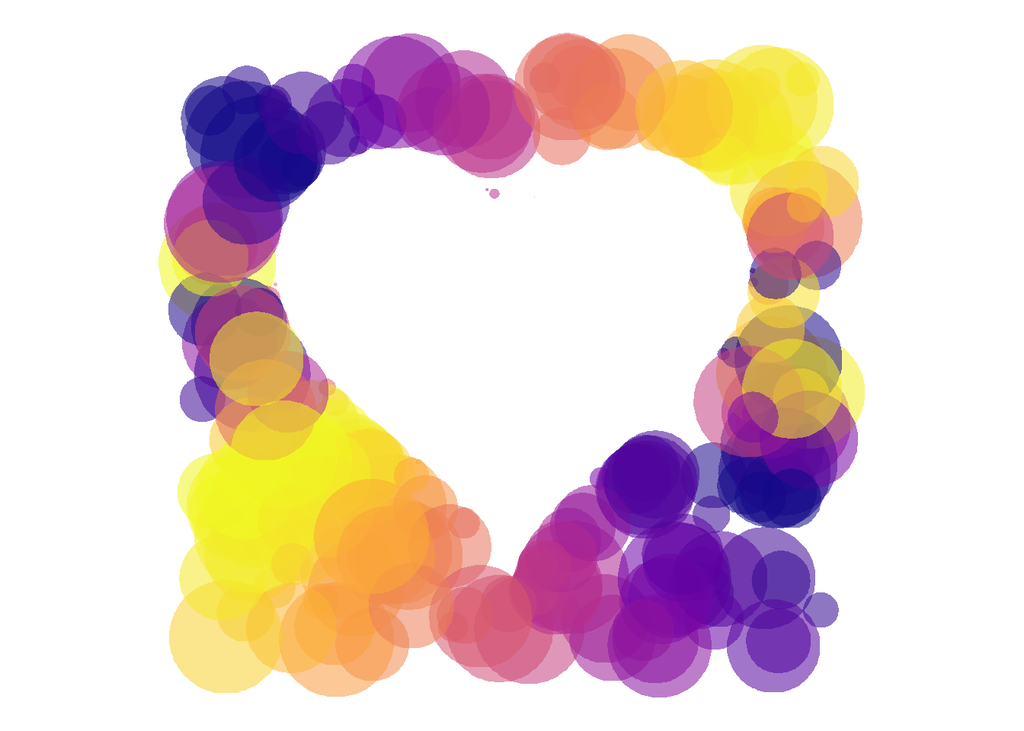

```r
heart_fun <- function(n) {
  t <- c(seq(0, 2 * pi, length.out = n), 0)

  out <- data.frame(
    x = c(16 * sin(t) ^ 3),
    y = 13 * cos(t) - 5 * cos(2 * t) - 2 * cos(3 * t) - cos(4 * t)
  )
  out <- as.matrix(out)
  out <- list(out)
  st_polygon(out)
}

circle_fun <- function(n) {
  t <- c(seq(0, 2 * pi, length.out = n), 0)

  out <- data.frame(
    x = sin(t),
    y = cos(t)
  )
  out <- as.matrix(out)
  out <- list(out)
  st_polygon(out)
}

circle_heart <- function(n, center_sf, outside_sf, outside_filter = "None", plotting_margin = 5, ...) {

  bound <- function(x, limit) {
    ifelse(x > limit, runif(1, limit / 4, limit), x)
  }

  range <- st_bbox(center_sf)
  points <- data.frame(x = runif(n, range[["xmin"]] - plotting_margin,
                                    range[["xmax"]] + plotting_margin),
                       y = runif(n, range[["ymin"]] - plotting_margin,
                                    range[["ymax"]] + plotting_margin)) %>%
    sf::st_as_sf(coords = c(1, 2))

  if (outside_filter == "buffer") {
    points <- st_intersection(points, st_buffer(center_sf, plotting_margin))
  }

  points <- points[!lengths(st_intersects(points, center_sf)), ]

  all_polygons <- map(points[[1]],
    ~ (outside_sf * bound(st_distance(center_sf, .x, by_element = TRUE), 4)) + .x) %>%
  st_sfc()

  plotting_data <- data.frame(all_polygons) %>%
  mutate(x = map_dbl(geometry, ~st_centroid(.x)[[1]]),
         y = map_dbl(geometry, ~st_centroid(.x)[[2]]))

  plotting_data %>%
    ggplot() +
    geom_sf(..., mapping = aes(geometry = geometry)) +
    coord_sf(datum = NA) +
    theme_void()
}

circle_heart(300, heart_fun(100), circle_fun(100), color = NA) +
  aes(fill = sin(x / y), alpha = 0.1) +
  scale_fill_viridis_c(option = "plasma") +
  guides(color = "none", fill = "none", alpha = "none")
```

*This analysis was done with lots of help from Julia Silge and David Robinson’s book, [Text Mining with R](https://www.tidytextmining.com/index.html). The code for the heart at the end was modified (well, basically stolen) from [this blog post](https://www.hvitfeldt.me/blog/circle-love-making-hearts-with-circles/) by Emil Hvitfeldt.*